# Introducción

La tecnología ha avanzado muy rápido desde la llegada de la inteligencia artificial, gracias a diferentes factores es posible hoy en día tener herramientas que hace unos años eran inalcanzables. Hay muchos modelos computacionales que permiten la interacción con el usuario para desarrollar tareas complejas que va desde el análisis de datos hasta indicaciones precisas para poder resolver dichos problemas, uno de estos modelos son las Redes Neuronales Recurrentes (RNN)\cite{ibm_2023}. Las RNN son una clase de redes neuronales que permiten el procesamiento de datos de una manera más fácil ya que son capaces de retener información previa a través de sus conexiones internas haciéndolas ideales para problemas como procesamiento del lenguaje natural, ayudando a la creación de chatbots, resumir textos, traducción, entre otros.

Mediante el uso de una técnica llamada ''embedding´´ es posible representar caracteres o palabras como vectores de números reales en un espacio de alta dimensión, de esta forma es más fácil poder recordar la secuencia de los números para poder reconocer relación entre las palabras. En este reporte se quiere poder trabajar con un modelo para poder evaluar su desempeño y poder modificar diferentes parámetros y lograr observar de qué forma puede desempeñar una mejor tarea. El código se desarrollo en el lenguaje Python a través de Google Collab Pro para poder acceder a procesos computacionales más rápidos.

# Análisis

Las RNN son muy usadas en el procesamiento de lenguaje natural debido a su gran capacidad de poder recordar mediante conexiones recurrentes, lo que significa que la salida de una unidad en un momento dado se retroalimenta como entrada en el siguiente paso de tiempo. La RNN actualiza en cada capa su estado interno debido a la información de las capas pasadas y dando paso a nueva información para capas futuras. Se han desarrollado diferentes variantes para poder trabajar diferentes problemas dependiendo de su naturaleza, algunos ejemplos son LSTM y GRU, estas variantes usan un gradiente de desvanecimiento diferente.

En este modelo se hace uso de Long Short-Term Memory (LSTM), las LSTM fueron creadas por Sepp Hochreiter y Jürgen Schmidhuber en 1997. El funcionamiento de las LSTM, en cada paso de tiempo, toman tres entradas: la entrada actual, la salida del paso de tiempo anterior y el estado anterior de la celda de memoria, y mediante funciones de activación, generalmente es la sigmoide. A diferencia de las RNN, estas son capaces de recordar información para intervalos de tiempo largos, como en la traducción automática\cite{LSTM1}. Las LSTM son usadas en varias cosas donde generalmente es crucial recodar grandes cantidades de caracteres.

Las LSTM hoy en día son muy usadas debido a su manejo efectivo de dependencias a largo plazo, su amplia versatilidad en diferentes aplicaciones, su fácil adaptabilidad con nuevas tecnologías emergentes, que es un modelo avanzado, y que constantemente hay investigación alrededor de las LSTM para poder mejorarlas.

Se espera poder desarrollar un modelo que funcione y se pueden modificar sus parámetros para poder obtener un modelo mejor optimizado, dentro de las aplicacionesm son muy grandes, un claro ejemplo es ChatGPT, donde puedes tener una plática y puedes solicitar diferentes tareas; otro ejemplo son los chatbots, estos tienen menos capacidad para realizar tareas, pero funcionan como una interfaz entre el usuario y toda la computación por detrás para poder resolver algún problema.

```python
import tensorflow
from tensorflow import keras
import torchtext
import gc
```

```python
!pip install portalocker
```

# Diseño

La preparación de datos es fundamental para poder meter los datos a un modelo, sirven principalmente para limpiar los datos y ordenarlos en un formato adecuado donde sea más fácil el procesamiento, por ejemplo la división en varios conjuntos, de entrenamiento y validación.

Primeor se cargan los datos desde un conjunto de datos WikiText-2. Este conjunto de datos incluye conjuntos de entrenamiento, validación y prueba.

```python
train_dataset, valid_dataset, test_dataset = torchtext.datasets.WikiText2()
```

```python
X_train_text = [text for text in train_dataset]
len(X_train_text)
```

```
36718
```

Se crea un tokenizador para poder introducirlo en el set de entrenamientos, para poder construir un vocabulario de caracteres

```python
from keras.preprocessing.text import Tokenizer

tokenizer = Tokenizer(char_level=True)

tokenizer.fit_on_texts(X_train_text)
```

```python
print(tokenizer.word_index)
```

```
{' ': 1, 'e': 2, 't': 3, 'a': 4, 'n': 5, 'i': 6, 'o': 7, 'r': 8, 's': 9, 'h': 10, 'd': 11, 'l': 12, 'u': 13, 'c': 14, 'm': 15, 'f': 16, 'g': 17, 'p': 18, 'w': 19, 'b': 20, 'y': 21, 'k': 22, ',': 23, '.': 24, 'v': 25, '<': 26, '>': 27, '@': 28, '\n': 29, '1': 30, '0': 31, '=': 32, '"': 33, '2': 34, "…
```

En este paso, se itera sobre los diferentes textos y crea secuencias de entrada de longitud y su etiqueta correspondiente y se añaden a los sets de entrenamiento para finalmente convertirlas en arrys de Numpy para poder usarlo más fácilmente en el entrenamiento del modelo. Se usa una longitud de secuencia de 100 caracteres inicialmente

```python
%%time

import numpy as np
train_dataset, valid_dataset, test_dataset = torchtext.datasets.WikiText2()

seq_length = 100
X_train, Y_train = [], []

for text in X_train_text[:6000]:
    for i in range(0, len(text)-seq_length):
        inp_seq = text[i:i+seq_length].lower()
        out_seq = text[i+seq_length].lower()
        X_train.append(inp_seq)
        Y_train.append(tokenizer.word_index[out_seq])

X_train = tokenizer.texts_to_sequences(X_train)

X_train, Y_train = np.array(X_train, dtype=np.int32), np.array(Y_train)

X_train.shape, Y_train.shape
```

```
CPU times: user 28.9 s, sys: 630 ms, total: 29.5 s
Wall time: 29.4 s
```

```
((1377719, 100), (1377719,))
```

Se puede observar que primero se declara la longitud de embedding, es decir, la longitud de los vectores para cada palabra; después viene la dimensión de unidades de la capa LSTM. Por parte del modelo, consta por 4 capas, la primera es una capa de Embedding la cual convierte los índices de palabras en vectores de tamaño, donde el tamaño del vocabulario está declarado por "input_dim" y se le suma 1 y la extensión del vector de entrada está declarado por "input_length"; después continuan dos capas de LSTM, la primera que sirve para poder devolver la secuencia completa a la siguiente capa en cada instante, lo cuál es muy relevante para la conexción entre las capas, y la segunda capa, a diferencia de la anterior, devuelve únicamente la salida del último paso; por último viene una capa Dense, la cual funciona como una capa de salida con la función de activación softmax que sirve para poder obetener una distribución de probabilidad sobre las palabras de vocabulario.

```python
from tensorflow.keras.models import Sequential
from tensorflow.keras.layers import LSTM, Dense, Embedding

embed_len = 50
lstm_out = 256

model = Sequential([
                    Embedding(input_dim=len(tokenizer.word_index)+1, output_dim=embed_len,
                              input_length=seq_length),
                    LSTM(lstm_out, return_sequences=True),
                    LSTM(lstm_out),
                    Dense(len(tokenizer.word_index)+1, activation="softmax")
                ])


model.summary()
```

```
Model: "sequential_3"
_________________________________________________________________
 Layer (type)                Output Shape              Param #
=================================================================
 embedding_3 (Embedding)     (None, 100, 50)           12200

 lstm_6 (LSTM)               (None, 100, 256)          314368

 lstm_7 (LSTM)               (None, 256)               525312

 dense_3 (Dense)             (None, 244)               62708

=================================================================
Total params: 914588 (3.49 MB)
Trainable params: 914588 (3.49 MB)
Non-trainable params: 0 (0.00 Byte)
_________________________________________________________________
```

Se hacen callbacks para poder seguir el rendimiento del modelo en cada epoch y así se puede guardar el modelo usado. Se almacena en un archivo llamado "mi_modelo_checkpoint.hdf5". Y el modelo se guardará solo si en cada monmento va mejorando

```python
from tensorflow.keras.callbacks import ModelCheckpoint

filepath = "mi_modelo_checkpoint.hdf5"
checkpoint = ModelCheckpoint(filepath, monitor='loss', verbose=1, save_best_only=True, mode='min')
```

Se compila le modelo con un optimizaro de Adam y se declara una tasa de aprendizaje de 0.001 junto con el parámetro de pérdida "sparse_categorical_crossentropy".

```python
from tensorflow.keras.optimizers import Adam
from keras import backend as K

model.compile(optimizer=Adam(learning_rate=0.001), loss="sparse_categorical_crossentropy")
```

```python
history = model.fit(X_train, Y_train, validation_split=0.2, batch_size=1024, epochs=50, callbacks=[checkpoint])
```

```
Epoch 1: loss improved from inf to 2.54777, saving model to mi_modelo_checkpoint.hdf5
```

```
Epoch 2: loss improved from 2.54777 to 2.03734, saving model to mi_modelo_checkpoint.hdf5
Epoch 3: loss improved from 2.03734 to 1.85543, saving model to mi_modelo_checkpoint.hdf5
Epoch 4: loss improved from 1.85543 to 1.75940, saving model to mi_modelo_checkpoint.hdf5
Epoch 5: loss improved from 1.75940 to 1.69643, saving model to mi_modelo_checkpoint.hdf5
Epoch 6: loss improved from 1.69643 to 1.63135, saving model to mi_modelo_checkpoint.hdf5
Epoch 7: loss improved from 1.63135 to 1.58034, saving model to mi_modelo_checkpoint.hdf5
Epoch 8: loss improved from 1.58034 to 1.54032, saving model to mi_modelo_checkpoint.hdf5
Epoch 9: loss improved from 1.54032 to 1.50717, saving model to mi_modelo_checkpoint.hdf5
Epoch 10: loss improved from 1.50717 to 1.47757, saving model to mi_modelo_checkpoint.hdf5
Epoch 11: loss improved from 1.47757 to 1.45190, saving model to mi_modelo_checkpoint.hdf5
Epoch 12: loss improved from 1.45190 to 1.43091, saving model to mi_modelo_checkpoint.hdf5
Epoch 13: loss improved from 1.43091 to 1.40903, saving model to mi_modelo_checkpoint.hdf5
Epoch 14: loss improved from 1.40903 to 1.38998, saving model to mi_modelo_checkpoint.hdf5
Epoch 15: loss improved from 1.38998 to 1.38092, saving model to mi_modelo_checkpoint.hdf5
Epoch 16: loss improved from 1.38092 to 1.36586, saving model to mi_modelo_checkpoint.hdf5
Epoch 17: loss improved from 1.36586 to 1.34618, saving model to mi_modelo_checkpoint.hdf5
Epoch 18: loss improved from 1.34618 to 1.33385, saving model to mi_modelo_checkpoint.hdf5
Epoch 19: loss did not improve from 1.33385
Epoch 20: loss did not improve from 1.33385
Epoch 21: loss improved from 1.33385 to 1.32269, saving model to mi_modelo_checkpoint.hdf5
Epoch 22: loss improved from 1.32269 to 1.30891, saving model to mi_modelo_checkpoint.hdf5
Epoch 23: loss improved from 1.30891 to 1.29723, saving model to mi_modelo_checkpoint.hdf5
Epoch 24: loss improved from 1.29723 to 1.28613, saving model to mi_modelo_checkpoint.hdf5
Epoch 25: loss improved from 1.28613 to 1.27611, saving model to mi_modelo_checkpoint.hdf5
Epoch 26: loss improved from 1.27611 to 1.26629, saving model to mi_modelo_checkpoint.hdf5
Epoch 27: loss improved from 1.26629 to 1.25751, saving model to mi_modelo_checkpoint.hdf5
Epoch 28: loss improved from 1.25751 to 1.24889, saving model to mi_modelo_checkpoint.hdf5
Epoch 29: loss improved from 1.24889 to 1.24111, saving model to mi_modelo_checkpoint.hdf5
Epoch 30: loss improved from 1.24111 to 1.23354, saving model to mi_modelo_checkpoint.hdf5
Epoch 31: loss improved from 1.23354 to 1.22653, saving model to mi_modelo_checkpoint.hdf5
Epoch 32: loss improved from 1.22653 to 1.21955, saving model to mi_modelo_checkpoint.hdf5
Epoch 33: loss improved from 1.21955 to 1.21267, saving model to mi_modelo_checkpoint.hdf5
Epoch 34: loss improved from 1.21267 to 1.20653, saving model to mi_modelo_checkpoint.hdf5
Epoch 35: loss improved from 1.20653 to 1.20023, saving model to mi_modelo_checkpoint.hdf5
Epoch 36: loss improved from 1.20023 to 1.19426, saving model to mi_modelo_checkpoint.hdf5
Epoch 37: loss improved from 1.19426 to 1.18880, saving model to mi_modelo_checkpoint.hdf5
Epoch 38: loss improved from 1.18880 to 1.18318, saving model to mi_modelo_checkpoint.hdf5
Epoch 39: loss improved from 1.18318 to 1.17768, saving model to mi_modelo_checkpoint.hdf5
Epoch 40: loss improved from 1.17768 to 1.17254, saving model to mi_modelo_checkpoint.hdf5
Epoch 41: loss improved from 1.17254 to 1.16737, saving model to mi_modelo_checkpoint.hdf5
Epoch 42: loss improved from 1.16737 to 1.16218, saving model to mi_modelo_checkpoint.hdf5
Epoch 43: loss improved from 1.16218 to 1.15761, saving model to mi_modelo_checkpoint.hdf5
Epoch 44: loss improved from 1.15761 to 1.15240, saving model to mi_modelo_checkpoint.hdf5
Epoch 45: loss improved from 1.15240 to 1.14820, saving model to mi_modelo_checkpoint.hdf5
Epoch 46: loss improved from 1.14820 to 1.14309, saving model to mi_modelo_checkpoint.hdf5
Epoch 47: loss improved from 1.14309 to 1.13913, saving model to mi_modelo_checkpoint.hdf5
Epoch 48: loss improved from 1.13913 to 1.13443, saving model to mi_modelo_checkpoint.hdf5
Epoch 49: loss improved from 1.13443 to 1.13033, saving model to mi_modelo_checkpoint.hdf5
Epoch 50: loss improved from 1.13033 to 1.12602, saving model to mi_modelo_checkpoint.hdf5
```

Se guarda el historial en un archivo tipo json.

```python
import json
with open('historial_entrenamiento.json', 'w') as f:
    json.dump(history.history, f)
```

Se grafica la pérdida de ambos set de entrenamiento, se puede observar como para el set de entrenamiento disminuye a más de 1.2 pero para el de validación se puede percibir cómo va aumentando nuevamente indicando overfitting

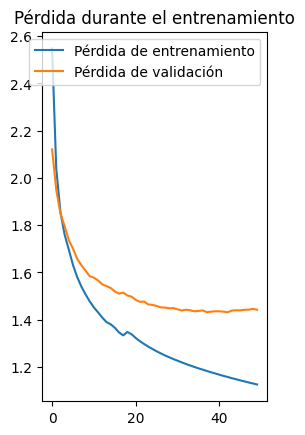

```python
import matplotlib.pyplot as plt

plt.subplot(1, 2, 2)
plt.plot(history.history['loss'], label='Pérdida de entrenamiento')
plt.plot(history.history['val_loss'], label='Pérdida de validación')
plt.title('Pérdida durante el entrenamiento')
plt.legend()

plt.show()
```

Se quiere poner a prueba el modelo, primero se declara una semilla aleatoria para poder hacer un for para generar 100 caracteres mediante la probabilidad y lo añade a la lista

```python
import random

random.seed(123)
idx = random.randint(0, len(X_train))
pattern = X_train[idx].flatten().tolist()

print("Initial Pattern : {}".format("".join([tokenizer.index_word[idx] for idx in pattern])))

generated_text = []
for i in range(100):
    X_batch = np.array(pattern, dtype=np.int32).reshape(1, seq_length) ## Design Batch
    preds = model.predict(X_batch) ## Make Prediction
    predicted_index = preds.argmax(axis=-1)[0] ## Retrieve token index
    generated_text.append(predicted_index) ## Add token index to result
    pattern.append(predicted_index) ## Add token index to original pattern
    pattern = pattern[1:] ## Resize pattern to bring again to seq_length length.

print("Generated Text : {}".format("".join([tokenizer.index_word[idx] for idx in generated_text])))
```

```
Initial Pattern : 1987 – 88 season where he was named the ihl 's co @-@ rookie of the year and most valuable player af
Generated Text : ter the state of the second construction of the second producer , and the construction of the second
```

Se puede observar el texto predecido con un poco de coherencia pero con palabras que sí existen.

# Se agrega dropout

Se quiere hacer un modelo con 2 capas de dropout. El embedding length y la dimensión del LSTM se mantiene igual. Consiste en una red neuronal similar pero agregando 2 capas de Dropout, cada una después de cada capa LSTM. Esto para ayudar a prevenir el sobreajuste disminuyendo aleatoriamente un porcentaje de las conexiones durante el entrenamiento. De igual forma se guarda el modelo.

```python
from tensorflow.keras.models import Sequential
from tensorflow.keras.layers import LSTM, Dense, Embedding, Dropout
from tensorflow.keras.optimizers import Adam
from keras import backend as K
from tensorflow.keras.callbacks import ModelCheckpoint
import json

embed_len = 50
lstm_out = 256
dropout_rate = 0.5

model1 = Sequential([
    Embedding(input_dim=len(tokenizer.word_index)+1, output_dim=embed_len,
                              input_length=seq_length),
    LSTM(lstm_out, return_sequences=True),
    Dropout(dropout_rate),
    LSTM(lstm_out),
    Dropout(dropout_rate),
    Dense(len(tokenizer.word_index)+1, activation="softmax")
])


filepath = "mi_modelo_checkpoint_dropout.hdf5"

checkpoint = ModelCheckpoint(filepath, monitor='loss', verbose=1, save_best_only=True, mode='min')


model1.compile(optimizer=Adam(learning_rate=0.001), loss="sparse_categorical_crossentropy")
history1 = model1.fit(X_train, Y_train, validation_split=0.2, batch_size=1024, epochs=50, callbacks=[checkpoint])

with open('historial_entrenamiento_dropout.json', 'w') as f:
    json.dump(history1.history, f)
```

```
Epoch 1: loss improved from inf to 2.56095, saving model to mi_modelo_checkpoint_dropout.hdf5
```

```
Epoch 2: loss improved from 2.56095 to 2.07879, saving model to mi_modelo_checkpoint_dropout.hdf5
Epoch 3: loss improved from 2.07879 to 1.96853, saving model to mi_modelo_checkpoint_dropout.hdf5
Epoch 4: loss improved from 1.96853 to 1.87873, saving model to mi_modelo_checkpoint_dropout.hdf5
Epoch 5: loss improved from 1.87873 to 1.82392, saving model to mi_modelo_checkpoint_dropout.hdf5
Epoch 6: loss improved from 1.82392 to 1.78036, saving model to mi_modelo_checkpoint_dropout.hdf5
Epoch 7: loss improved from 1.78036 to 1.74468, saving model to mi_modelo_checkpoint_dropout.hdf5
Epoch 8: loss improved from 1.74468 to 1.71435, saving model to mi_modelo_checkpoint_dropout.hdf5
Epoch 9: loss did not improve from 1.71435
Epoch 10: loss improved from 1.71435 to 1.67568, saving model to mi_modelo_checkpoint_dropout.hdf5
Epoch 11: loss improved from 1.67568 to 1.65694, saving model to mi_modelo_checkpoint_dropout.hdf5
Epoch 12: loss improved from 1.65694 to 1.64120, saving model to mi_modelo_checkpoint_dropout.hdf5
Epoch 13: loss improved from 1.64120 to 1.62635, saving model to mi_modelo_checkpoint_dropout.hdf5
Epoch 14: loss improved from 1.62635 to 1.61201, saving model to mi_modelo_checkpoint_dropout.hdf5
Epoch 15: loss improved from 1.61201 to 1.60034, saving model to mi_modelo_checkpoint_dropout.hdf5
Epoch 16: loss improved from 1.60034 to 1.58887, saving model to mi_modelo_checkpoint_dropout.hdf5
Epoch 17: loss improved from 1.58887 to 1.57791, saving model to mi_modelo_checkpoint_dropout.hdf5
Epoch 18: loss improved from 1.57791 to 1.56829, saving model to mi_modelo_checkpoint_dropout.hdf5
Epoch 19: loss improved from 1.56829 to 1.55902, saving model to mi_modelo_checkpoint_dropout.hdf5
Epoch 20: loss improved from 1.55902 to 1.55163, saving model to mi_modelo_checkpoint_dropout.hdf5
Epoch 21: loss improved from 1.55163 to 1.54361, saving model to mi_modelo_checkpoint_dropout.hdf5
Epoch 22: loss improved from 1.54361 to 1.53763, saving model to mi_modelo_checkpoint_dropout.hdf5
Epoch 23: loss improved from 1.53763 to 1.53068, saving model to mi_modelo_checkpoint_dropout.hdf5
Epoch 24: loss improved from 1.53068 to 1.52380, saving model to mi_modelo_checkpoint_dropout.hdf5
Epoch 25: loss improved from 1.52380 to 1.51698, saving model to mi_modelo_checkpoint_dropout.hdf5
Epoch 26: loss improved from 1.51698 to 1.51195, saving model to mi_modelo_checkpoint_dropout.hdf5
Epoch 27: loss did not improve from 1.51195
Epoch 28: loss improved from 1.51195 to 1.50292, saving model to mi_modelo_checkpoint_dropout.hdf5
Epoch 29: loss improved from 1.50292 to 1.49700, saving model to mi_modelo_checkpoint_dropout.hdf5
Epoch 30: loss improved from 1.49700 to 1.49497, saving model to mi_modelo_checkpoint_dropout.hdf5
Epoch 31: loss improved from 1.49497 to 1.49099, saving model to mi_modelo_checkpoint_dropout.hdf5
Epoch 32: loss improved from 1.49099 to 1.48846, saving model to mi_modelo_checkpoint_dropout.hdf5
Epoch 33: loss improved from 1.48846 to 1.48378, saving model to mi_modelo_checkpoint_dropout.hdf5
Epoch 34: loss improved from 1.48378 to 1.48109, saving model to mi_modelo_checkpoint_dropout.hdf5
Epoch 35: loss improved from 1.48109 to 1.47796, saving model to mi_modelo_checkpoint_dropout.hdf5
Epoch 36: loss improved from 1.47796 to 1.47547, saving model to mi_modelo_checkpoint_dropout.hdf5
Epoch 37: loss improved from 1.47547 to 1.47231, saving model to mi_modelo_checkpoint_dropout.hdf5
Epoch 38: loss improved from 1.47231 to 1.46842, saving model to mi_modelo_checkpoint_dropout.hdf5
Epoch 39: loss improved from 1.46842 to 1.46495, saving model to mi_modelo_checkpoint_dropout.hdf5
Epoch 40: loss improved from 1.46495 to 1.46162, saving model to mi_modelo_checkpoint_dropout.hdf5
Epoch 41: loss improved from 1.46162 to 1.45935, saving model to mi_modelo_checkpoint_dropout.hdf5
Epoch 42: loss improved from 1.45935 to 1.45678, saving model to mi_modelo_checkpoint_dropout.hdf5
Epoch 43: loss improved from 1.45678 to 1.45426, saving model to mi_modelo_checkpoint_dropout.hdf5
Epoch 44: loss improved from 1.45426 to 1.45194, saving model to mi_modelo_checkpoint_dropout.hdf5
Epoch 45: loss improved from 1.45194 to 1.44925, saving model to mi_modelo_checkpoint_dropout.hdf5
Epoch 46: loss improved from 1.44925 to 1.44759, saving model to mi_modelo_checkpoint_dropout.hdf5
Epoch 47: loss improved from 1.44759 to 1.44578, saving model to mi_modelo_checkpoint_dropout.hdf5
Epoch 48: loss improved from 1.44578 to 1.44232, saving model to mi_modelo_checkpoint_dropout.hdf5
Epoch 49: loss improved from 1.44232 to 1.44067, saving model to mi_modelo_checkpoint_dropout.hdf5
Epoch 50: loss improved from 1.44067 to 1.43849, saving model to mi_modelo_checkpoint_dropout.hdf5
```

Se grafica la pérdida para poder ver compararla con la anterior. En la gráfica se puede observar cómo convergen en un punto ambos sets lo que significa que no hay un sobreajuste como en el modelo anterior pero la pérdida no baja tanto como el modelo, lo que puede ser señal que no aprende tanto como el anterior.

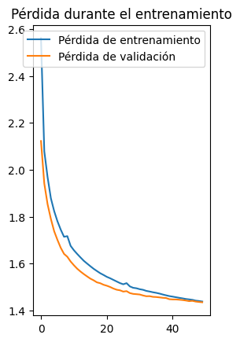

```python
import matplotlib.pyplot as plt

plt.subplot(1, 2, 2)
plt.plot(history1.history['loss'], label='Pérdida de entrenamiento')
plt.plot(history1.history['val_loss'], label='Pérdida de validación')
plt.title('Pérdida durante el entrenamiento')
plt.legend()

plt.show()
```

```python
import random

random.seed(123)
idx = random.randint(0, len(X_train))
pattern = X_train[idx].flatten().tolist()

print("Initial Pattern : {}".format("".join([tokenizer.index_word[idx] for idx in pattern])))

generated_text = []
for i in range(100):
    X_batch = np.array(pattern, dtype=np.int32).reshape(1, seq_length)
    preds = model1.predict(X_batch)
    predicted_index = preds.argmax(axis=-1)[0]
    generated_text.append(predicted_index)
    pattern.append(predicted_index)
    pattern = pattern[1:]

print("Generated Text : {}".format("".join([tokenizer.index_word[idx] for idx in generated_text])))
```

```
Initial Pattern : 1987 – 88 season where he was named the ihl 's co @-@ rookie of the year and most valuable player af
Generated Text : ter the season .
ather and the second state of the season of the season of the season , and the sea
```

Se puede observar como se forman las palabras pero igualmente sin sentido, se puede ver cómo se repiten las palabras por lo que puede ser debido a que no aprendió bien.

# Con 150 palabras y learning rate de 0.0005

```python
%%time

import numpy as np
train_dataset, valid_dataset, test_dataset = torchtext.datasets.WikiText2()

seq_length = 150
X_train, Y_train = [], []

for text in X_train_text[:6000]:
    for i in range(0, len(text)-seq_length):
        inp_seq = text[i:i+seq_length].lower()
        out_seq = text[i+seq_length].lower()
        X_train.append(inp_seq)
        Y_train.append(tokenizer.word_index[out_seq])

X_train = tokenizer.texts_to_sequences(X_train)

X_train, Y_train = np.array(X_train, dtype=np.int32), np.array(Y_train)

X_train.shape, Y_train.shape
```

```
CPU times: user 38.6 s, sys: 847 ms, total: 39.4 s
Wall time: 39.3 s
```

```
((1260002, 150), (1260002,))
```

Como se mencionó, se usa el primer modelo.

```python
from tensorflow.keras.models import Sequential
from tensorflow.keras.layers import LSTM, Dense, Embedding, Dropout
from tensorflow.keras.optimizers import Adam
from keras import backend as K
from tensorflow.keras.callbacks import ModelCheckpoint
import json

embed_len = 50
lstm_out = 256

model2 = Sequential([
                    Embedding(input_dim=len(tokenizer.word_index)+1, output_dim=embed_len,
                              input_length=seq_length),
                    LSTM(lstm_out, return_sequences=True),
                    LSTM(lstm_out),
                    Dense(len(tokenizer.word_index)+1, activation="softmax")
                ])

filepath = "mi_modelo_checkpoint_150.hdf5"

checkpoint = ModelCheckpoint(filepath, monitor='loss', verbose=1, save_best_only=True, mode='min')


model2.compile(optimizer=Adam(learning_rate=0.0005), loss="sparse_categorical_crossentropy")
history2 = model2.fit(X_train, Y_train, validation_split=0.2, batch_size=1024, epochs=50, callbacks=[checkpoint])


with open('historial_entrenamiento_150.json', 'w') as f:
    json.dump(history2.history, f)
```

```
Epoch 1: loss improved from inf to 2.81179, saving model to mi_modelo_checkpoint_150.hdf5
Epoch 2: loss improved from 2.81179 to 2.19162, saving model to mi_modelo_checkpoint_150.hdf5
Epoch 3: loss improved from 2.19162 to 2.03249, saving model to mi_modelo_checkpoint_150.hdf5
Epoch 4: loss improved from 2.03249 to 1.96058, saving model to mi_modelo_checkpoint_150.hdf5
Epoch 5: loss improved from 1.96058 to 1.88259, saving model to mi_modelo_checkpoint_150.hdf5
Epoch 6: loss improved from 1.88259 to 1.81137, saving model to mi_modelo_checkpoint_150.hdf5
Epoch 7: loss improved from 1.81137 to 1.77490, saving model to mi_modelo_checkpoint_150.hdf5
Epoch 8: loss improved from 1.77490 to 1.72161, saving model to mi_modelo_checkpoint_150.hdf5
Epoch 9: loss improved from 1.72161 to 1.69048, saving model to mi_modelo_checkpoint_150.hdf5
Epoch 10: loss improved from 1.69048 to 1.63947, saving model to mi_modelo_checkpoint_150.hdf5
Epoch 11: loss improved from 1.63947 to 1.59613, saving model to mi_modelo_checkpoint_150.hdf5
Epoch 12: loss improved from 1.59613 to 1.57878, saving model to mi_modelo_checkpoint_150.hdf5
Epoch 13: loss improved from 1.57878 to 1.55286, saving model to mi_modelo_checkpoint_150.hdf5
Epoch 14: loss improved from 1.55286 to 1.52787, saving model to mi_modelo_checkpoint_150.hdf5
Epoch 15: loss improved from 1.52787 to 1.50054, saving model to mi_modelo_checkpoint_150.hdf5
Epoch 16: loss improved from 1.50054 to 1.45483, saving model to mi_modelo_checkpoint_150.hdf5
Epoch 17: loss improved from 1.45483 to 1.44327, saving model to mi_modelo_checkpoint_150.hdf5
Epoch 18: loss did not improve from 1.44327
Epoch 19: loss did not improve from 1.44327
Epoch 20: loss did not improve from 1.44327
Epoch 21: loss did not improve from 1.44327
Epoch 22: loss did not improve from 1.44327
Epoch 23: loss did not improve from 1.44327
Epoch 24: loss improved from 1.44327 to 1.43571, saving model to mi_modelo_checkpoint_150.hdf5
Epoch 25: loss improved from 1.43571 to 1.42260, saving model to mi_modelo_checkpoint_150.hdf5
Epoch 26: loss improved from 1.42260 to 1.41013, saving model to mi_modelo_checkpoint_150.hdf5
Epoch 27: loss improved from 1.41013 to 1.39838, saving model to mi_modelo_checkpoint_150.hdf5
Epoch 28: loss improved from 1.39838 to 1.38735, saving model to mi_modelo_checkpoint_150.hdf5
Epoch 29: loss improved from 1.38735 to 1.37722, saving model to mi_modelo_checkpoint_150.hdf5
Epoch 30: loss improved from 1.37722 to 1.36731, saving model to mi_modelo_checkpoint_150.hdf5
Epoch 31: loss improved from 1.36731 to 1.35798, saving model to mi_modelo_checkpoint_150.hdf5
Epoch 32: loss improved from 1.35798 to 1.34904, saving model to mi_modelo_checkpoint_150.hdf5
Epoch 33: loss improved from 1.34904 to 1.34089, saving model to mi_modelo_checkpoint_150.hdf5
Epoch 34: loss improved from 1.34089 to 1.33285, saving model to mi_modelo_checkpoint_150.hdf5
Epoch 35: loss improved from 1.33285 to 1.32477, saving model to mi_modelo_checkpoint_150.hdf5
Epoch 36: loss improved from 1.32477 to 1.31770, saving model to mi_modelo_checkpoint_150.hdf5
Epoch 37: loss improved from 1.31770 to 1.30986, saving model to mi_modelo_checkpoint_150.hdf5
Epoch 38: loss improved from 1.30986 to 1.30392, saving model to mi_modelo_checkpoint_150.hdf5
Epoch 39: loss improved from 1.30392 to 1.29679, saving model to mi_modelo_checkpoint_150.hdf5
Epoch 40: loss improved from 1.29679 to 1.29067, saving model to mi_modelo_checkpoint_150.hdf5
Epoch 41: loss improved from 1.29067 to 1.28480, saving model to mi_modelo_checkpoint_150.hdf5
Epoch 42: loss improved from 1.28480 to 1.27845, saving model to mi_modelo_checkpoint_150.hdf5
Epoch 43: loss improved from 1.27845 to 1.27293, saving model to mi_modelo_checkpoint_150.hdf5
Epoch 44: loss improved from 1.27293 to 1.26928, saving model to mi_modelo_checkpoint_150.hdf5
Epoch 45: loss improved from 1.26928 to 1.26321, saving model to mi_modelo_checkpoint_150.hdf5
Epoch 46: loss improved from 1.26321 to 1.25735, saving model to mi_modelo_checkpoint_150.hdf5
Epoch 47: loss improved from 1.25735 to 1.25209, saving model to mi_modelo_checkpoint_150.hdf5
Epoch 48: loss improved from 1.25209 to 1.24716, saving model to mi_modelo_checkpoint_150.hdf5
Epoch 49: loss improved from 1.24716 to 1.24241, saving model to mi_modelo_checkpoint_150.hdf5
Epoch 50: loss improved from 1.24241 to 1.23756, saving model to mi_modelo_checkpoint_150.hdf5
```

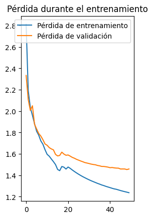

```python
import matplotlib.pyplot as plt

plt.subplot(1, 2, 2)
plt.plot(history2.history['loss'], label='Pérdida de entrenamiento')
plt.plot(history2.history['val_loss'], label='Pérdida de validación')
plt.title('Pérdida durante el entrenamiento')
plt.legend()

plt.show()
```

```python
import random

random.seed(123)
idx = random.randint(0, len(X_train))
pattern = X_train[idx].flatten().tolist()

print("Initial Pattern : {}".format("".join([tokenizer.index_word[idx] for idx in pattern])))

generated_text = []
for i in range(100):
    X_batch = np.array(pattern, dtype=np.int32).reshape(1, seq_length)
    preds = model2.predict(X_batch)
    predicted_index = preds.argmax(axis=-1)[0]
    generated_text.append(predicted_index)
    pattern.append(predicted_index)
    pattern = pattern[1:]

print("Generated Text : {}".format("".join([tokenizer.index_word[idx] for idx in generated_text])))
```

```
Initial Pattern :  home port of pola , in present @-@ day croatia , except for four engagements . in 1914 , she formed part of the austro @-@ hungarian flotilla sent to
Generated Text :  the state of the season .
eceived the second state of the second control of the season .
eceived
```

# AdaMax

```python
from tensorflow.keras.models import Sequential
from tensorflow.keras.layers import LSTM, Dense, Embedding, Dropout
from tensorflow.keras.optimizers import Adamax
from keras import backend as K
from tensorflow.keras.callbacks import ModelCheckpoint
import json

embed_len = 50
lstm_out = 256

model3 = Sequential([
                    Embedding(input_dim=len(tokenizer.word_index)+1, output_dim=embed_len,
                              input_length=seq_length),
                    LSTM(lstm_out, return_sequences=True),
                    LSTM(lstm_out),
                    Dense(len(tokenizer.word_index)+1, activation="softmax")
                ])

filepath = "mi_modelo_checkpoint_AdaMax.hdf5"

checkpoint = ModelCheckpoint(filepath, monitor='loss', verbose=1, save_best_only=True, mode='min')

model3.compile(optimizer=Adamax(learning_rate=0.001), loss="sparse_categorical_crossentropy")
history3 = model3.fit(X_train, Y_train, validation_split=0.2, batch_size=1024, epochs=50, callbacks=[checkpoint])

with open('historial_entrenamiento_AdaMax.json', 'w') as f:
    json.dump(history3.history, f)
```

```
Epoch 1: loss improved from inf to 2.95531, saving model to mi_modelo_checkpoint_AdaMax.hdf5
```

```
Epoch 2: loss improved from 2.95531 to 2.36840, saving model to mi_modelo_checkpoint_AdaMax.hdf5
Epoch 3: loss improved from 2.36840 to 2.15888, saving model to mi_modelo_checkpoint_AdaMax.hdf5
Epoch 4: loss improved from 2.15888 to 2.03792, saving model to mi_modelo_checkpoint_AdaMax.hdf5
Epoch 5: loss improved from 2.03792 to 1.95222, saving model to mi_modelo_checkpoint_AdaMax.hdf5
Epoch 6: loss improved from 1.95222 to 1.88636, saving model to mi_modelo_checkpoint_AdaMax.hdf5
Epoch 7: loss improved from 1.88636 to 1.83304, saving model to mi_modelo_checkpoint_AdaMax.hdf5
Epoch 8: loss improved from 1.83304 to 1.78803, saving model to mi_modelo_checkpoint_AdaMax.hdf5
Epoch 9: loss improved from 1.78803 to 1.74942, saving model to mi_modelo_checkpoint_AdaMax.hdf5
Epoch 10: loss improved from 1.74942 to 1.71533, saving model to mi_modelo_checkpoint_AdaMax.hdf5
Epoch 11: loss improved from 1.71533 to 1.68489, saving model to mi_modelo_checkpoint_AdaMax.hdf5
Epoch 12: loss improved from 1.68489 to 1.65755, saving model to mi_modelo_checkpoint_AdaMax.hdf5
Epoch 13: loss improved from 1.65755 to 1.63303, saving model to mi_modelo_checkpoint_AdaMax.hdf5
Epoch 14: loss improved from 1.63303 to 1.61033, saving model to mi_modelo_checkpoint_AdaMax.hdf5
Epoch 15: loss improved from 1.61033 to 1.58959, saving model to mi_modelo_checkpoint_AdaMax.hdf5
Epoch 16: loss improved from 1.58959 to 1.57042, saving model to mi_modelo_checkpoint_AdaMax.hdf5
Epoch 17: loss improved from 1.57042 to 1.55263, saving model to mi_modelo_checkpoint_AdaMax.hdf5
Epoch 18: loss improved from 1.55263 to 1.53630, saving model to mi_modelo_checkpoint_AdaMax.hdf5
Epoch 19: loss improved from 1.53630 to 1.52144, saving model to mi_modelo_checkpoint_AdaMax.hdf5
Epoch 20: loss improved from 1.52144 to 1.50735, saving model to mi_modelo_checkpoint_AdaMax.hdf5
Epoch 21: loss improved from 1.50735 to 1.49436, saving model to mi_modelo_checkpoint_AdaMax.hdf5
Epoch 22: loss improved from 1.49436 to 1.48194, saving model to mi_modelo_checkpoint_AdaMax.hdf5
Epoch 23: loss improved from 1.48194 to 1.47037, saving model to mi_modelo_checkpoint_AdaMax.hdf5
Epoch 24: loss improved from 1.47037 to 1.45948, saving model to mi_modelo_checkpoint_AdaMax.hdf5
Epoch 25: loss improved from 1.45948 to 1.44943, saving model to mi_modelo_checkpoint_AdaMax.hdf5
Epoch 26: loss improved from 1.44943 to 1.43980, saving model to mi_modelo_checkpoint_AdaMax.hdf5
Epoch 27: loss improved from 1.43980 to 1.43061, saving model to mi_modelo_checkpoint_AdaMax.hdf5
Epoch 28: loss improved from 1.43061 to 1.42189, saving model to mi_modelo_checkpoint_AdaMax.hdf5
Epoch 29: loss improved from 1.42189 to 1.41418, saving model to mi_modelo_checkpoint_AdaMax.hdf5
Epoch 30: loss improved from 1.41418 to 1.40612, saving model to mi_modelo_checkpoint_AdaMax.hdf5
Epoch 31: loss improved from 1.40612 to 1.39880, saving model to mi_modelo_checkpoint_AdaMax.hdf5
Epoch 32: loss improved from 1.39880 to 1.39139, saving model to mi_modelo_checkpoint_AdaMax.hdf5
Epoch 33: loss improved from 1.39139 to 1.38451, saving model to mi_modelo_checkpoint_AdaMax.hdf5
Epoch 34: loss improved from 1.38451 to 1.37812, saving model to mi_modelo_checkpoint_AdaMax.hdf5
Epoch 35: loss improved from 1.37812 to 1.37174, saving model to mi_modelo_checkpoint_AdaMax.hdf5
Epoch 36: loss improved from 1.37174 to 1.36564, saving model to mi_modelo_checkpoint_AdaMax.hdf5
Epoch 37: loss improved from 1.36564 to 1.35961, saving model to mi_modelo_checkpoint_AdaMax.hdf5
Epoch 38: loss improved from 1.35961 to 1.35411, saving model to mi_modelo_checkpoint_AdaMax.hdf5
Epoch 39: loss improved from 1.35411 to 1.34853, saving model to mi_modelo_checkpoint_AdaMax.hdf5
Epoch 40: loss improved from 1.34853 to 1.34326, saving model to mi_modelo_checkpoint_AdaMax.hdf5
Epoch 41: loss improved from 1.34326 to 1.33829, saving model to mi_modelo_checkpoint_AdaMax.hdf5
Epoch 42: loss improved from 1.33829 to 1.33331, saving model to mi_modelo_checkpoint_AdaMax.hdf5
Epoch 43: loss improved from 1.33331 to 1.32871, saving model to mi_modelo_checkpoint_AdaMax.hdf5
Epoch 44: loss improved from 1.32871 to 1.32384, saving model to mi_modelo_checkpoint_AdaMax.hdf5
Epoch 45: loss improved from 1.32384 to 1.31928, saving model to mi_modelo_checkpoint_AdaMax.hdf5
Epoch 46: loss improved from 1.31928 to 1.31483, saving model to mi_modelo_checkpoint_AdaMax.hdf5
Epoch 47: loss improved from 1.31483 to 1.31080, saving model to mi_modelo_checkpoint_AdaMax.hdf5
Epoch 48: loss improved from 1.31080 to 1.30651, saving model to mi_modelo_checkpoint_AdaMax.hdf5
Epoch 49: loss improved from 1.30651 to 1.30239, saving model to mi_modelo_checkpoint_AdaMax.hdf5
Epoch 50: loss improved from 1.30239 to 1.29840, saving model to mi_modelo_checkpoint_AdaMax.hdf5
```

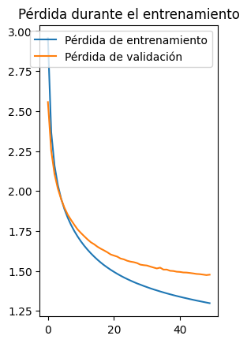

```python
import matplotlib.pyplot as plt

plt.subplot(1, 2, 2)
plt.plot(history3.history['loss'], label='Pérdida de entrenamiento')
plt.plot(history3.history['val_loss'], label='Pérdida de validación')
plt.title('Pérdida durante el entrenamiento')
plt.legend()

plt.show()
```

```python
import random

random.seed(123)
idx = random.randint(0, len(X_train))
pattern = X_train[idx].flatten().tolist()

print("Initial Pattern : {}".format("".join([tokenizer.index_word[idx] for idx in pattern])))

generated_text = []
for i in range(100):
    X_batch = np.array(pattern, dtype=np.int32).reshape(1, seq_length)
    preds = model3.predict(X_batch)
    predicted_index = preds.argmax(axis=-1)[0]
    generated_text.append(predicted_index)
    pattern.append(predicted_index)
    pattern = pattern[1:]

print("Generated Text : {}".format("".join([tokenizer.index_word[idx] for idx in generated_text])))
```

[output not shown]

Aquí ya empieza unicamente a memorizar la palabra state, lo que puede significar que se está sobreentrenando con los modelos anteriores.

# 200 palabras y 80 de embedding

Por último se quiere hacer un modelo que pueda entrenarse a partir de 200 palabras y con una longitud de embedding de 80 caracteres.

```python
%%time

import numpy as np
train_dataset, valid_dataset, test_dataset = torchtext.datasets.WikiText2()

seq_length = 200
X_train, Y_train = [], []

for text in X_train_text[:6000]:
    for i in range(0, len(text)-seq_length):
        inp_seq = text[i:i+seq_length].lower()
        out_seq = text[i+seq_length].lower()
        X_train.append(inp_seq)
        Y_train.append(tokenizer.word_index[out_seq])

X_train = tokenizer.texts_to_sequences(X_train)

X_train, Y_train = np.array(X_train, dtype=np.int32), np.array(Y_train)

X_train.shape, Y_train.shape
```

```
CPU times: user 45.5 s, sys: 1.11 s, total: 46.6 s
Wall time: 46.5 s
```

```
((1148042, 200), (1148042,))
```

Como se mencionó, se mantiene la estructura original pero ahora se cambia la longitud de embedding.

```python
from tensorflow.keras.models import Sequential
from tensorflow.keras.layers import LSTM, Dense, Embedding, Dropout
from tensorflow.keras.optimizers import Adam
from keras import backend as K
from tensorflow.keras.callbacks import ModelCheckpoint
import json

embed_len = 80
lstm_out = 256

model4 = Sequential([
                    Embedding(input_dim=len(tokenizer.word_index)+1, output_dim=embed_len,
                              input_length=seq_length),
                    LSTM(lstm_out, return_sequences=True),
                    LSTM(lstm_out),
                    Dense(len(tokenizer.word_index)+1, activation="softmax")
                ])

filepath = "mi_modelo_checkpoint_200.hdf5"

checkpoint = ModelCheckpoint(filepath, monitor='loss', verbose=1, save_best_only=True, mode='min')

model4.compile(optimizer=Adam(learning_rate=0.001), loss="sparse_categorical_crossentropy")
history4 = model4.fit(X_train, Y_train, validation_split=0.2, batch_size=1024, epochs=50, callbacks=[checkpoint])

with open('historial_entrenamiento_200.json', 'w') as f:
    json.dump(history4.history, f)
```

```
Epoch 1: loss improved from inf to 2.54992, saving model to mi_modelo_checkpoint_200.hdf5
```

```
Epoch 2: loss improved from 2.54992 to 2.04410, saving model to mi_modelo_checkpoint_200.hdf5
Epoch 3: loss improved from 2.04410 to 1.82485, saving model to mi_modelo_checkpoint_200.hdf5
Epoch 4: loss improved from 1.82485 to 1.64384, saving model to mi_modelo_checkpoint_200.hdf5
Epoch 5: loss improved from 1.64384 to 1.61221, saving model to mi_modelo_checkpoint_200.hdf5
Epoch 6: loss did not improve from 1.61221
Epoch 7: loss improved from 1.61221 to 1.58695, saving model to mi_modelo_checkpoint_200.hdf5
Epoch 8: loss improved from 1.58695 to 1.55319, saving model to mi_modelo_checkpoint_200.hdf5
Epoch 9: loss improved from 1.55319 to 1.49391, saving model to mi_modelo_checkpoint_200.hdf5
Epoch 10: loss improved from 1.49391 to 1.46083, saving model to mi_modelo_checkpoint_200.hdf5
Epoch 11: loss improved from 1.46083 to 1.43194, saving model to mi_modelo_checkpoint_200.hdf5
Epoch 12: loss improved from 1.43194 to 1.41196, saving model to mi_modelo_checkpoint_200.hdf5
Epoch 13: loss improved from 1.41196 to 1.39194, saving model to mi_modelo_checkpoint_200.hdf5
Epoch 14: loss improved from 1.39194 to 1.38131, saving model to mi_modelo_checkpoint_200.hdf5
Epoch 15: loss improved from 1.38131 to 1.37495, saving model to mi_modelo_checkpoint_200.hdf5
Epoch 16: loss improved from 1.37495 to 1.36652, saving model to mi_modelo_checkpoint_200.hdf5
Epoch 17: loss improved from 1.36652 to 1.35807, saving model to mi_modelo_checkpoint_200.hdf5
Epoch 18: loss improved from 1.35807 to 1.33991, saving model to mi_modelo_checkpoint_200.hdf5
Epoch 19: loss improved from 1.33991 to 1.32699, saving model to mi_modelo_checkpoint_200.hdf5
Epoch 20: loss improved from 1.32699 to 1.31152, saving model to mi_modelo_checkpoint_200.hdf5
Epoch 21: loss improved from 1.31152 to 1.29690, saving model to mi_modelo_checkpoint_200.hdf5
Epoch 22: loss improved from 1.29690 to 1.28466, saving model to mi_modelo_checkpoint_200.hdf5
Epoch 23: loss improved from 1.28466 to 1.27524, saving model to mi_modelo_checkpoint_200.hdf5
Epoch 24: loss improved from 1.27524 to 1.26679, saving model to mi_modelo_checkpoint_200.hdf5
Epoch 25: loss improved from 1.26679 to 1.26106, saving model to mi_modelo_checkpoint_200.hdf5
Epoch 26: loss improved from 1.26106 to 1.25779, saving model to mi_modelo_checkpoint_200.hdf5
Epoch 27: loss improved from 1.25779 to 1.24785, saving model to mi_modelo_checkpoint_200.hdf5
Epoch 28: loss improved from 1.24785 to 1.23741, saving model to mi_modelo_checkpoint_200.hdf5
Epoch 29: loss improved from 1.23741 to 1.22700, saving model to mi_modelo_checkpoint_200.hdf5
Epoch 30: loss improved from 1.22700 to 1.21780, saving model to mi_modelo_checkpoint_200.hdf5
Epoch 31: loss improved from 1.21780 to 1.21105, saving model to mi_modelo_checkpoint_200.hdf5
Epoch 32: loss improved from 1.21105 to 1.20235, saving model to mi_modelo_checkpoint_200.hdf5
Epoch 33: loss improved from 1.20235 to 1.19396, saving model to mi_modelo_checkpoint_200.hdf5
Epoch 34: loss did not improve from 1.19396
Epoch 35: loss did not improve from 1.19396
Epoch 36: loss did not improve from 1.19396
Epoch 37: loss did not improve from 1.19396
Epoch 38: loss did not improve from 1.19396
Epoch 39: loss did not improve from 1.19396
Epoch 40: loss did not improve from 1.19396
Epoch 41: loss improved from 1.19396 to 1.18863, saving model to mi_modelo_checkpoint_200.hdf5
Epoch 42: loss improved from 1.18863 to 1.18523, saving model to mi_modelo_checkpoint_200.hdf5
Epoch 43: loss improved from 1.18523 to 1.17903, saving model to mi_modelo_checkpoint_200.hdf5
Epoch 44: loss improved from 1.17903 to 1.16976, saving model to mi_modelo_checkpoint_200.hdf5
Epoch 45: loss improved from 1.16976 to 1.16676, saving model to mi_modelo_checkpoint_200.hdf5
Epoch 46: loss improved from 1.16676 to 1.16361, saving model to mi_modelo_checkpoint_200.hdf5
Epoch 47: loss improved from 1.16361 to 1.15650, saving model to mi_modelo_checkpoint_200.hdf5
Epoch 48: loss improved from 1.15650 to 1.14720, saving model to mi_modelo_checkpoint_200.hdf5
Epoch 49: loss did not improve from 1.14720
Epoch 50: loss did not improve from 1.14720
```

Se puede observar la gráfica de pérdida en donde se ve mucho ruido, se observa que el loss baja mucho pero al igual que el primer modelo, el set de validación da indicios de overfitting, por lo que no es un buen modelo.

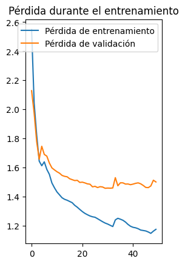

```python
import matplotlib.pyplot as plt

plt.subplot(1, 2, 2)
plt.plot(history4.history['loss'], label='Pérdida de entrenamiento')
plt.plot(history4.history['val_loss'], label='Pérdida de validación')
plt.title('Pérdida durante el entrenamiento')
plt.legend()

plt.show()
```

```python
import random

random.seed(123)
idx = random.randint(0, len(X_train))
pattern = X_train[idx].flatten().tolist()

print("Initial Pattern : {}".format("".join([tokenizer.index_word[idx] for idx in pattern])))

generated_text = []
for i in range(100):
    X_batch = np.array(pattern, dtype=np.int32).reshape(1, seq_length)
    preds = model4.predict(X_batch)
    predicted_index = preds.argmax(axis=-1)[0]
    generated_text.append(predicted_index)
    pattern.append(predicted_index)
    pattern = pattern[1:]

print("Generated Text : {}".format("".join([tokenizer.index_word[idx] for idx in generated_text])))
```

```
Initial Pattern : es , spreading and <unk> the worship of the old local deities . but others have argued that the most important predynastic gods were , like other elements of egyptian culture , present all across the
Generated Text : state of the series of the series of the series , and the state of the season , and the starts and t
```

Se puede observar cómo se aprende diferentes palabras en su mayoría que comiencen con "s". Se escriben palabras sin mucho sentido pero las escribe bien.

# Problemas Encontrados

A lo largo de los diferentes modelos encontrados, se pudo observar que en casi todas las predicciones sí logra generar palabras aunque poco sin sentido. Además, el tiempo de procesamiento para poder completar todo el entrenamiento fue demasiado, por lo que mediante una computadora con mayor procesador puede disminuir el tiempo y dar paso a modelos más complejos o al exploramiento de más parámetros. En todas las gráficas excepto en el modelo que se agregó dropout, se puede ver como no convergen el set de entrenamiento con el de validación pero que sí disminuyen. Por el mismo tiempo de procesamiento no puede ser muy fácil el poder entrenar con muchos caracteres, por lo que se podría mejorar el modelo si se pudiera dar un vector más largo.

# Conclusión

Los diferentes modelos utilizados dan paso a un área que ya está bastante explorada y que tiene muchísimas aplicaciones. Los modelos sí mostraron un buen comportamiento en la pérdida, lo que muestra que sí mejora epoch por epoch. A pesar de que las predicciones no son las mejores sí muestran palabras bien escritas sin formar una oración coherente, sí forman frases pero no oraciones coherentes. Para poder mejorar el modelo, es posible hacer diferentes cosas para poder mejorar los modelos.

1. Más epochs para entrenar más tiempo
2. Hacer un modelo más largo para poder mejorar el aprendimiento
3. Conseguir una computadora con mayor procesamiento computacional
4. Probar con otro tipo de redes neuronales
5. Probar diferentes parámetros.

# Referencias

Solanki, S. (2022) Keras: Rnns (LSTM) for text generation (character embeddings) by Sunny Solanki, Developed for Developers by Developer for the betterment of Development. Available at: https://coderzcolumn.com/tutorials/artificial-intelligence/keras-text-generation-using-rnn-and-character-embeddings (Accessed: 24 November 2023).

¿Qué son las redes neuronales recurrentes? (no date) IBM. Available at: https://www.ibm.com/mx-es/topics/recurrent-neural-networks (Accessed: 24 November 2023).

English, M.L. in P. (2023) Recurrent neural network - lesson 6: Embeddings and word representations, Medium. Available at: https://medium.com/@nerdjock/recurrent-neural-network-lesson-6-embeddings-and-word-representations-c456f9ce5c69 (Accessed: 24 November 2023).

Team, K. (no date) Keras Documentation: Adam, Keras. Available at: https://keras.io/api/optimizers/adam/ (Accessed: 24 November 2023).

Chollet, F. (2017). Deep learning with python. Manning Publications.